# Fuel Economy

(October 26, 2022)

Fuel economy is particularly important for the automobile industry. The purpose of this assignment is to write an R script to present graphically a correlation matrix, to identify the various features which may impact fuel economy (miles per gallon) and to construct a regression model in order to predict the fuel consumption of future car brands according to the various features of the car.

# Packages Needed

install.packages(“corrplot”)  
install.packages(“psych”)  
install.packages(“ggplot2”)  
install.packages(“reshape2”)  
install.packages(“DT”)

# Libraries

```r
library(corrplot)
library("psych")
library(ggplot2)
library(reshape2)
library(DT)
```

# Reading Data

We read the data from the csv file and saved into dataCar. We then printed the data to check it.

```r
cars <- read.csv("cars.csv")
dataCar <- cars
datatable(dataCar, rownames = FALSE, filter="top", options = list(pageLength = 5, scrollX=T) )
```

| brand | mpg | cyl | disp | hp | drat | wt | qsec | vs | am | gear | carb |
| --- | --- | --- | --- | --- | --- | --- | --- | --- | --- | --- | --- |
| Mazda RX4 | 21 | 6 | 160 | 110 | 3.9 | 2.62 | 16.46 | 0 | 1 | 4 | 4 |
| Mazda RX4 Wag | 21 | 6 | 160 | 110 | 3.9 | 2.875 | 17.02 | 0 | 1 | 4 | 4 |
| Datsun 710 | 22.8 | 4 | 108 | 93 | 3.85 | 2.32 | 18.61 | 1 | 1 | 4 | 1 |
| Hornet 4 Drive | 21.4 | 6 | 258 | 110 | 3.08 | 3.215 | 19.44 | 1 | 0 | 3 | 1 |
| Hornet Sportabout | 18.7 | 8 | 360 | 175 | 3.15 | 3.44 | 17.02 | 0 | 0 | 3 | 2 |
| Valiant | 18.1 | 6 | 225 | 105 | 2.76 | 3.46 | 20.22 | 1 | 0 | 3 | 1 |
| Duster 360 | 14.3 | 8 | 360 | 245 | 3.21 | 3.57 | 15.84 | 0 | 0 | 3 | 4 |
| Merc 240D | 24.4 | 4 | 146.7 | 62 | 3.69 | 3.19 | 20 | 1 | 0 | 4 | 2 |
| Merc 230 | 22.8 | 4 | 140.8 | 95 | 3.92 | 3.15 | 22.9 | 1 | 0 | 4 | 2 |
| Merc 280 | 19.2 | 6 | 167.6 | 123 | 3.92 | 3.44 | 18.3 | 1 | 0 | 4 | 4 |

[output cut: 22 more lines]

We need to delete the non-numerical part of the document, thus we updated our new table without the name of the cars and we called the variable carClean. We also used str to make sure that the brand was removed and the rest are not categorical.

```r
carClean <- dataCar[2:12]
str(carClean)
```

```
## 'data.frame':    32 obs. of  11 variables:
##  $ mpg : num  21 21 22.8 21.4 18.7 18.1 14.3 24.4 22.8 19.2 ...
##  $ cyl : int  6 6 4 6 8 6 8 4 4 6 ...
##  $ disp: num  160 160 108 258 360 ...
##  $ hp  : int  110 110 93 110 175 105 245 62 95 123 ...
##  $ drat: num  3.9 3.9 3.85 3.08 3.15 2.76 3.21 3.69 3.92 3.92 ...
##  $ wt  : num  2.62 2.88 2.32 3.21 3.44 ...
##  $ qsec: num  16.5 17 18.6 19.4 17 ...
##  $ vs  : int  0 0 1 1 0 1 0 1 1 1 ...
##  $ am  : int  1 1 1 0 0 0 0 0 0 0 ...
##  $ gear: int  4 4 4 3 3 3 3 4 4 4 ...
##  $ carb: int  4 4 1 1 2 1 4 2 2 4 ...
```

# Variables containing P-values

We created a variable to save the p-values choosing 0.95 as the confidence interval.

```r
corr_car_mat <- corr.test(carClean)$p
test = cor.mtest(carClean, conf.level = 0.95)
```

# Correlation Matrix

We attached our updated dataset to call the variables directly.

```r
attach(carClean)
## The following object is masked from package:ggplot2:
##
##     mpg
```

We plotted the correlation matrix according to circles

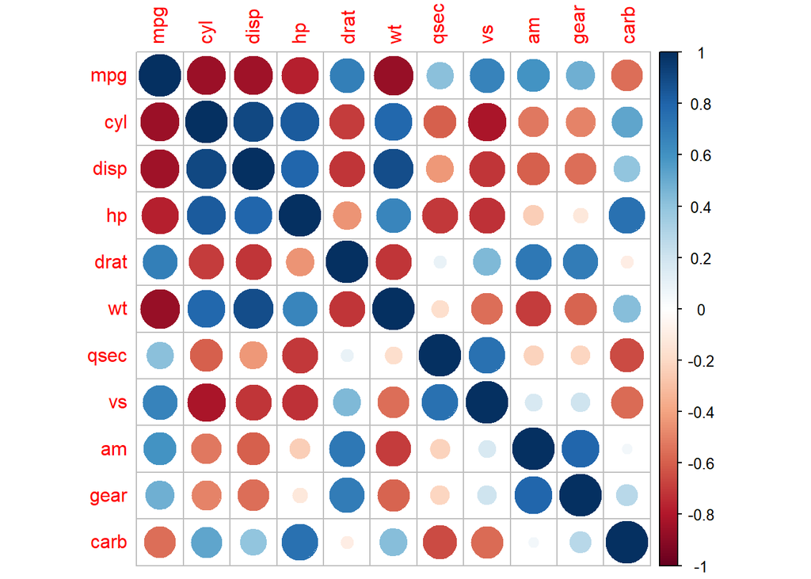

```r
corrplot(cor(carClean), method = "circle")
```

We plotted the correlation matrix according to numbers

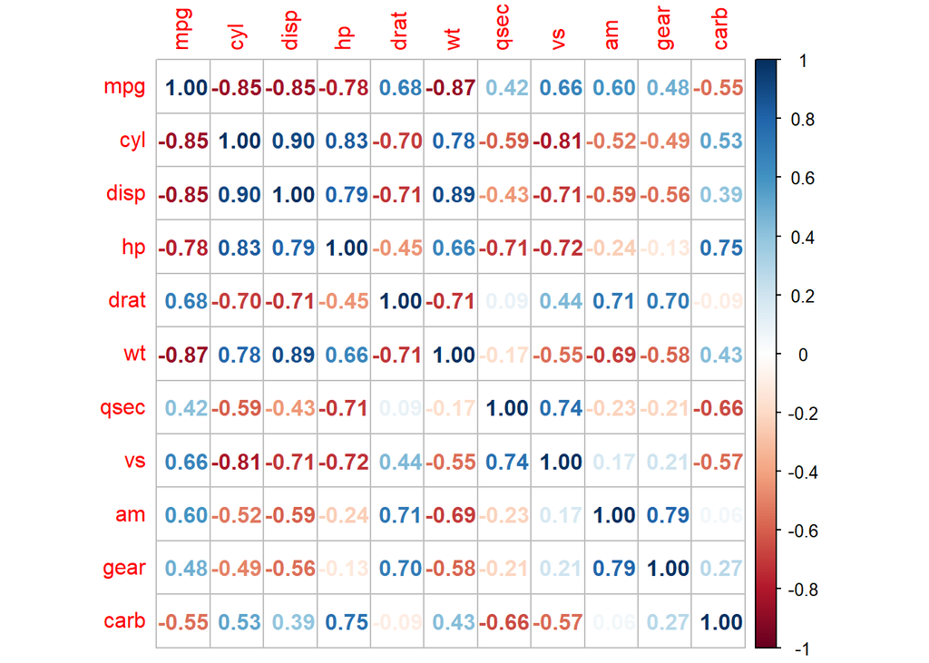

```r
corrplot(cor(carClean), method = "number")
```

The circle method makes it easier to see the significance among the variables, with the number method allowing us to get accurate values.

We crossed out insignificant correlations (in other words the p-value higher to 0.1 was crossed) and rearranged the rows and columns for a clearer pattern and better interpretation

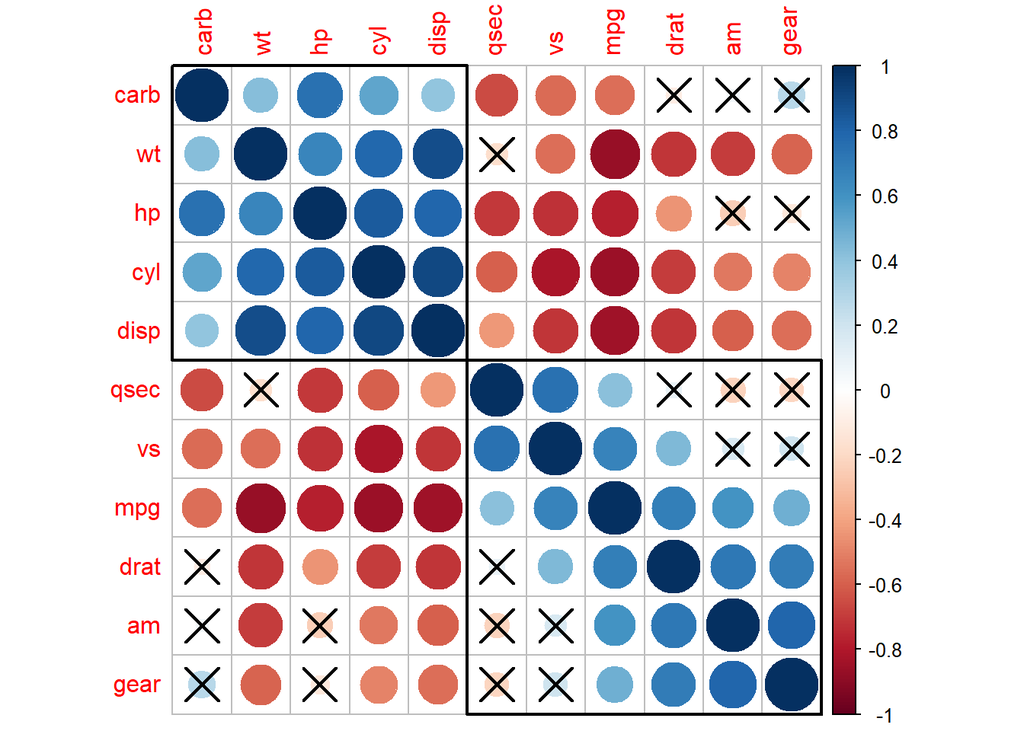

```r
corrplot(cor(carClean),p.mat = test$p, sig.level = 0.10, order = 'hclust', addrect = 2)
```

Using this plot, we can easily see the variables with positive correlation and those with negative correlation. In fact, the red colors of the represented circles in the correlation matrix show a negative correlation between feature, however, the blue colors show a positive correlation between features. The darker the colors (whether red or blue), the higher the value of positive or negative correlation. The lighter the color the slighter the correlation is existing between features. Furthermore, our correlation matrix, also shows that our output mgp (miles per gallons) has a relationship with our variable, as none was crossed out.

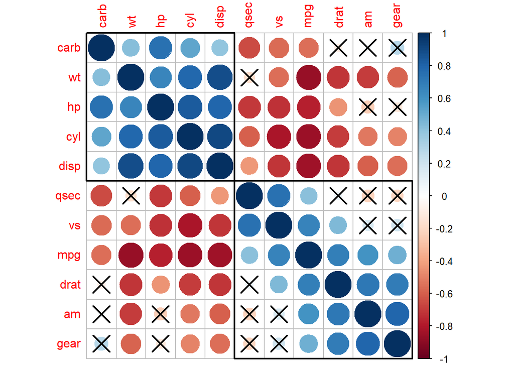

```r
corrplot(cor(carClean),p.mat = test$p, sig.level = 0.10, order = 'hclust', addrect = 2)
```

We can improve it further by removing duplicates. Hence, we showed half of the correlation matrix, knowing that the other missing part is symmetrical. To make that difference, we modified the type to lower.

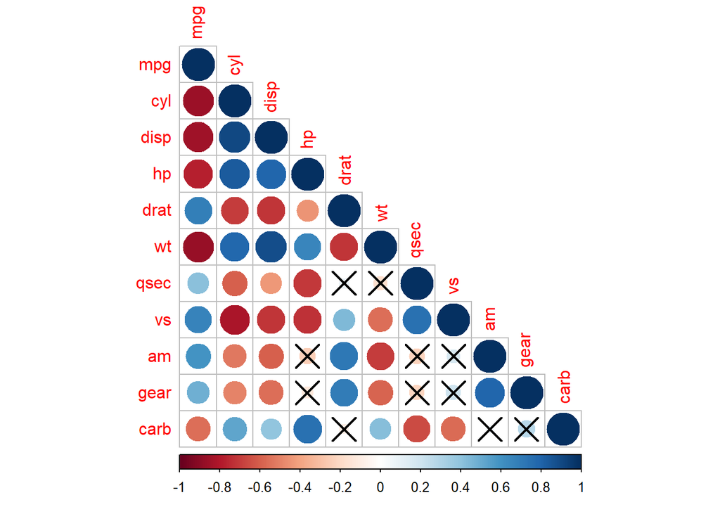

```r
corrplot(cor(carClean),p.mat = test$p, sig.level = 0.10 ,type = 'lower',  addrect = 2)
```

We transformed it into numbers as well for more accurate interpretations.

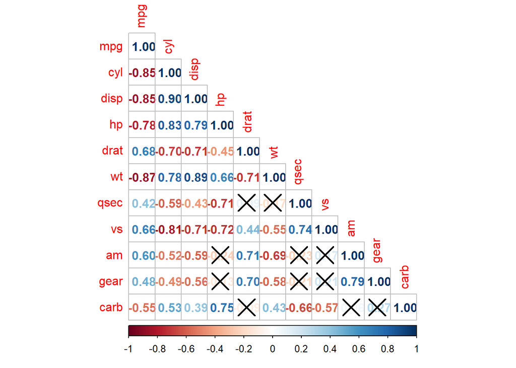

```r
corrplot(cor(carClean),p.mat = test$p, sig.level = 0.10 ,type = 'lower', method = "number", addrect = 2)
```

# Multiple Linear Regression Models

We constructed a multiple linear regression model with all the variables.

```r
lm.fit=lm(mpg~cyl+disp+hp+drat+wt+qsec+vs+am+gear+carb,data=carClean)
summary(lm.fit)
```

```
##
## Call:
## lm(formula = mpg ~ cyl + disp + hp + drat + wt + qsec + vs +
##     am + gear + carb, data = carClean)
##
## Residuals:
##     Min      1Q  Median      3Q     Max
## -3.4506 -1.6044 -0.1196  1.2193  4.6271
##
## Coefficients:
##             Estimate Std. Error t value Pr(>|t|)
## (Intercept) 12.30337   18.71788   0.657   0.5181
## cyl         -0.11144    1.04502  -0.107   0.9161
## disp         0.01334    0.01786   0.747   0.4635
## hp          -0.02148    0.02177  -0.987   0.3350
## drat         0.78711    1.63537   0.481   0.6353
## wt          -3.71530    1.89441  -1.961   0.0633 .
## qsec         0.82104    0.73084   1.123   0.2739
## vs           0.31776    2.10451   0.151   0.8814
## am           2.52023    2.05665   1.225   0.2340
## gear         0.65541    1.49326   0.439   0.6652
## carb        -0.19942    0.82875  -0.241   0.8122
## ---
## Signif. codes:  0 '***' 0.001 '**' 0.01 '*' 0.05 '.' 0.1 ' ' 1
##
## Residual standard error: 2.65 on 21 degrees of freedom
## Multiple R-squared:  0.869,  Adjusted R-squared:  0.8066
## F-statistic: 13.93 on 10 and 21 DF,  p-value: 3.793e-07
```

```r
lm.fit=lm(mpg~disp+hp+drat+wt+qsec+vs+am+gear+carb,data=carClean)
summary(lm.fit)
```

```
##
## Call:
## lm(formula = mpg ~ disp + hp + drat + wt + qsec + vs + am + gear +
##     carb, data = carClean)
##
## Residuals:
##     Min      1Q  Median      3Q     Max
## -3.4286 -1.5908 -0.0412  1.2120  4.5961
##
## Coefficients:
##             Estimate Std. Error t value Pr(>|t|)
## (Intercept) 10.96007   13.53030   0.810   0.4266
## disp         0.01283    0.01682   0.763   0.4538
## hp          -0.02191    0.02091  -1.048   0.3062
## drat         0.83520    1.53625   0.544   0.5921
## wt          -3.69251    1.83954  -2.007   0.0572 .
## qsec         0.84244    0.68678   1.227   0.2329
## vs           0.38975    1.94800   0.200   0.8433
## am           2.57743    1.94035   1.328   0.1977
## gear         0.71155    1.36562   0.521   0.6075
## carb        -0.21958    0.78856  -0.278   0.7833
## ---
## Signif. codes:  0 '***' 0.001 '**' 0.01 '*' 0.05 '.' 0.1 ' ' 1
##
## Residual standard error: 2.59 on 22 degrees of freedom
## Multiple R-squared:  0.8689, Adjusted R-squared:  0.8153
## F-statistic: 16.21 on 9 and 22 DF,  p-value: 9.031e-08
```

*Remove vs  
Second, we removed the engine configuration

```r
lm.fit=lm(mpg~disp+hp+drat+wt+qsec+am+gear+carb,data=carClean)
summary(lm.fit)
```

```
##
## Call:
## lm(formula = mpg ~ disp + hp + drat + wt + qsec + am + gear +
##     carb, data = carClean)
##
## Residuals:
##    Min     1Q Median     3Q    Max
## -3.356 -1.576 -0.149  1.218  4.604
##
## Coefficients:
##             Estimate Std. Error t value Pr(>|t|)
## (Intercept)  9.76828   11.89230   0.821   0.4199
## disp         0.01214    0.01612   0.753   0.4590
## hp          -0.02095    0.01993  -1.051   0.3040
## drat         0.87510    1.49113   0.587   0.5630
## wt          -3.71151    1.79834  -2.064   0.0505 .
## qsec         0.91083    0.58312   1.562   0.1319
## am           2.52390    1.88128   1.342   0.1928
## gear         0.75984    1.31577   0.577   0.5692
## carb        -0.24796    0.75933  -0.327   0.7470
## ---
## Signif. codes:  0 '***' 0.001 '**' 0.01 '*' 0.05 '.' 0.1 ' ' 1
##
## Residual standard error: 2.535 on 23 degrees of freedom
## Multiple R-squared:  0.8687, Adjusted R-squared:  0.823
## F-statistic: 19.02 on 8 and 23 DF,  p-value: 2.008e-08
```

*Remove carb  
Third, we removed the number of carburators

```r
lm.fit=lm(mpg~disp+hp+drat+wt+qsec+am+gear,data=carClean)
summary(lm.fit)
```

```
##
## Call:
## lm(formula = mpg ~ disp + hp + drat + wt + qsec + am + gear,
##     data = carClean)
##
## Residuals:
##     Min      1Q  Median      3Q     Max
## -3.1200 -1.7753 -0.1446  1.0903  4.7172
##
## Coefficients:
##             Estimate Std. Error t value Pr(>|t|)
## (Intercept)  9.19763   11.54220   0.797  0.43334
## disp         0.01552    0.01214   1.278  0.21342
## hp          -0.02471    0.01596  -1.548  0.13476
## drat         0.81023    1.45007   0.559  0.58151
## wt          -4.13065    1.23593  -3.342  0.00272 **
## qsec         1.00979    0.48883   2.066  0.04981 *
## am           2.58980    1.83528   1.411  0.17104
## gear         0.60644    1.20596   0.503  0.61964
## ---
## Signif. codes:  0 '***' 0.001 '**' 0.01 '*' 0.05 '.' 0.1 ' ' 1
##
## Residual standard error: 2.488 on 24 degrees of freedom
## Multiple R-squared:  0.8681, Adjusted R-squared:  0.8296
## F-statistic: 22.56 on 7 and 24 DF,  p-value: 4.218e-09
```

*Remove gear  
Fourth, we removed the number of forward gears

```r
lm.fit=lm(mpg~disp+hp+drat+wt+qsec+am,data=carClean)
summary(lm.fit)
```

```
##
## Call:
## lm(formula = mpg ~ disp + hp + drat + wt + qsec + am, data = carClean)
##
## Residuals:
##     Min      1Q  Median      3Q     Max
## -3.2669 -1.6148 -0.2585  1.1220  4.5564
##
## Coefficients:
##             Estimate Std. Error t value Pr(>|t|)
## (Intercept) 10.71062   10.97539   0.976  0.33848
## disp         0.01310    0.01098   1.193  0.24405
## hp          -0.02180    0.01465  -1.488  0.14938
## drat         1.02065    1.36748   0.746  0.46240
## wt          -4.04454    1.20558  -3.355  0.00254 **
## qsec         0.99073    0.48002   2.064  0.04955 *
## am           2.98469    1.63382   1.827  0.07969 .
## ---
## Signif. codes:  0 '***' 0.001 '**' 0.01 '*' 0.05 '.' 0.1 ' ' 1
##
## Residual standard error: 2.45 on 25 degrees of freedom
## Multiple R-squared:  0.8667, Adjusted R-squared:  0.8347
## F-statistic: 27.09 on 6 and 25 DF,  p-value: 8.637e-10
```

*Remove drat  
Fifth, we removed the rear axle ratio

```r
lm.fit=lm(mpg~disp+hp+wt+qsec+am,data=carClean)
summary(lm.fit)
```

```
##
## Call:
## lm(formula = mpg ~ disp + hp + wt + qsec + am, data = carClean)
##
## Residuals:
##     Min      1Q  Median      3Q     Max
## -3.5399 -1.7398 -0.3196  1.1676  4.5534
##
## Coefficients:
##             Estimate Std. Error t value Pr(>|t|)
## (Intercept) 14.36190    9.74079   1.474  0.15238
## disp         0.01124    0.01060   1.060  0.29897
## hp          -0.02117    0.01450  -1.460  0.15639
## wt          -4.08433    1.19410  -3.420  0.00208 **
## qsec         1.00690    0.47543   2.118  0.04391 *
## am           3.47045    1.48578   2.336  0.02749 *
## ---
## Signif. codes:  0 '***' 0.001 '**' 0.01 '*' 0.05 '.' 0.1 ' ' 1
##
## Residual standard error: 2.429 on 26 degrees of freedom
## Multiple R-squared:  0.8637, Adjusted R-squared:  0.8375
## F-statistic: 32.96 on 5 and 26 DF,  p-value: 1.844e-10
```

*Remove disp  
Sixth, we removed the displacement (total power the engine can generate)

```r
lm.fit=lm(mpg~hp+wt+qsec+am,data=carClean)
summary(lm.fit)
```

```
##
## Call:
## lm(formula = mpg ~ hp + wt + qsec + am, data = carClean)
##
## Residuals:
##     Min      1Q  Median      3Q     Max
## -3.4975 -1.5902 -0.1122  1.1795  4.5404
##
## Coefficients:
##             Estimate Std. Error t value Pr(>|t|)
## (Intercept) 17.44019    9.31887   1.871  0.07215 .
## hp          -0.01765    0.01415  -1.247  0.22309
## wt          -3.23810    0.88990  -3.639  0.00114 **
## qsec         0.81060    0.43887   1.847  0.07573 .
## am           2.92550    1.39715   2.094  0.04579 *
## ---
## Signif. codes:  0 '***' 0.001 '**' 0.01 '*' 0.05 '.' 0.1 ' ' 1
##
## Residual standard error: 2.435 on 27 degrees of freedom
## Multiple R-squared:  0.8579, Adjusted R-squared:  0.8368
## F-statistic: 40.74 on 4 and 27 DF,  p-value: 4.589e-11
```

*Remove hp  
Seventh, we removed the Gross horsepower

```r
lm.fit4=lm(mpg~wt+qsec+am,data=carClean)
summary(lm.fit4)
```

```
##
## Call:
## lm(formula = mpg ~ wt + qsec + am, data = carClean)
##
## Residuals:
##     Min      1Q  Median      3Q     Max
## -3.4811 -1.5555 -0.7257  1.4110  4.6610
##
## Coefficients:
##             Estimate Std. Error t value Pr(>|t|)
## (Intercept)   9.6178     6.9596   1.382 0.177915
## wt           -3.9165     0.7112  -5.507 6.95e-06 ***
## qsec          1.2259     0.2887   4.247 0.000216 ***
## am            2.9358     1.4109   2.081 0.046716 *
## ---
## Signif. codes:  0 '***' 0.001 '**' 0.01 '*' 0.05 '.' 0.1 ' ' 1
##
## Residual standard error: 2.459 on 28 degrees of freedom
## Multiple R-squared:  0.8497, Adjusted R-squared:  0.8336
## F-statistic: 52.75 on 3 and 28 DF,  p-value: 1.21e-11
```

```r
lm.fit2 = lm(mpg~wt*qsec+wt*am+qsec*am, data=carClean)
summary(lm.fit2)
```

```
##
## Call:
## lm(formula = mpg ~ wt * qsec + wt * am + qsec * am, data = carClean)
##
## Residuals:
##    Min     1Q Median     3Q    Max
## -3.401 -1.423 -0.489  1.138  4.021
##
## Coefficients:
##             Estimate Std. Error t value Pr(>|t|)
## (Intercept) -31.8598    33.5894  -0.949  0.35195
## wt            9.8362     9.8094   1.003  0.32560
## qsec          3.3188     1.8350   1.809  0.08255 .
## am           21.7151    15.8498   1.370  0.18285
## wt:qsec      -0.7114     0.5425  -1.311  0.20166
## wt:am        -4.7165     1.6643  -2.834  0.00896 **
## qsec:am      -0.3536     0.7094  -0.498  0.62250
## ---
## Signif. codes:  0 '***' 0.001 '**' 0.01 '*' 0.05 '.' 0.1 ' ' 1
##
## Residual standard error: 2.088 on 25 degrees of freedom
## Multiple R-squared:  0.9032, Adjusted R-squared:   0.88
## F-statistic: 38.89 on 6 and 25 DF,  p-value: 1.704e-11
```

The model will look like this:

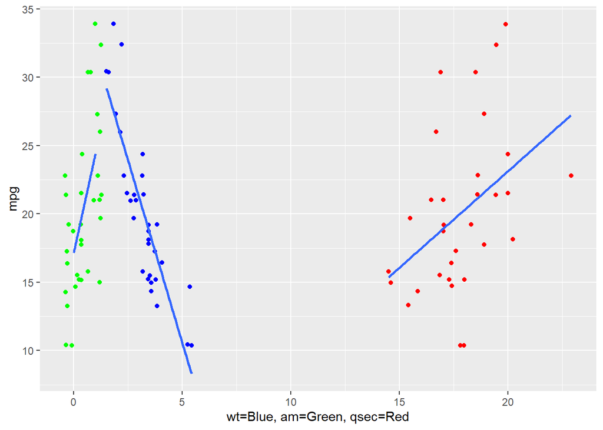

```r
ggplot(carClean) +
  geom_jitter(aes(wt,mpg), colour="blue") + geom_smooth(aes(wt,mpg), method=lm, se=FALSE) +
  geom_jitter(aes(am,mpg), colour="green") + geom_smooth(aes(am,mpg), method=lm, se=FALSE) +
  geom_jitter(aes(qsec,mpg), colour="red") + geom_smooth(aes(qsec,mpg), method=lm, se=FALSE) +
  labs(x = "wt=Blue, am=Green, qsec=Red", y = "mpg")
## `geom_smooth()` using formula 'y ~ x'
## `geom_smooth()` using formula 'y ~ x'
## `geom_smooth()` using formula 'y ~ x'
```

The result of the model is showing 3 lines: the correlation between mpg with each of wt, am and qsec. Based on the correlation matrix, the correlation between mpg and wt is classified as a big dark red color, which shows that it’s a highly negative correlation. Furthermore, in the case of am and qsec, the circle representing the correlation between am and mpg is darker and bigger than that representing the correlation between qsec and mpg. However, both are blue indicating a positive correlation. The graph proves these, as wt (line for blue points) is decreasing, qsec (line for red points) is increasing and am (line for green points) is increasing faster.

# Conclusion

In conclusion, we started with a model that contains all variables and wasn’t performing well, to a model that contains only 3 variables and highlighting our most significant variables. We also constructed the correlation matrix, removed the duplicates from it, color-coded the values, rearranged and formatted it to make it clearer. At the end, we were able to plot the linear regression model which showed the correlation between mgp and each of wt, am and qsec. It is also important to note that all the observation was used for training the model. The reason for this is that there aren’t a lot of observations, and splitting it would make it more difficult to predict a good model.